# Dealing with Data and Packages

May 7, 2019

# Extending R with packages

## Install the Tidyverse

We will be using a suite of packages designed for data science.

**$\Rightarrow$** Install the `tidyverse` by executing the following command in the console:

```r
install.packages("tidyverse")
```

This installation may take a few moments.

## Packages in R

- So far, we have been using “base” R.
- One of the most compelling reasons to use R is the enormous ecosystem of packages that extend its capabilities.
- [CRAN task view](https://cran.rstudio.com/web/views/)

# *Getting Data into R*

## Reproducibilty principles

- We want other people to be able to look at our data and reproduce our statistical analyses.
- We should make our data public.
- We should make our code public.
- Importing data into a statistical package often involves choices. These choices should be reproducible.
- Therefore, **our code should import our data.** Avoid using menus or mouse clicks to import data.

## Importing Data from a website

- In the last lesson, we read most of our data sets off of websites.
- For many R commands, `file` can be a path to a local file, or a URL.
- This is fairly reproducible. (It would be better if the code and data were in the same place.)

## Tidyverse packages for importing data

- `readxl` provides `read_excel`
- `readr` provides `read_csv`, `read_tsv`, `read_table`, `read_delim`, etc.

See help menus for details

## **$\Rightarrow$** Make a new project

1. In the *File* menu, choose *New Project…*. In the dialog that appears, select *New Directory* followed by *New Project*.
2. For the *Directory Name*, use `DataWorkshop`. Click on *Browse* and find a subdirectory where you want this new directory to reside (e.g., Documents, Dropbox, etc.). You will need to be able to find this directory later.
3. Click on *Create Project*. A new empty project should load. A file named `DataWorkshop.Rproj` should appear in the *Files* tab in the lower right pane.

## **$\Rightarrow$** Make a new RMarkdown document

1. In the *File* menu, choose *New File > RMarkdown…*.
2. In the “New R Markdown” dialog box, give the document a title. Keep the other default settings (Document, HTML).
3. Clicking OK will open a new RMarkdown document with some boilerplate code. *Delete* everything below line 7.
4. *Save* the document as `datatidy.Rmd` in the project directory `DataWorkshop`. After you save the file, it should appear in the *Files* tab, along with the file `DataWorkshop.Rproj`.

## Importing Data from a local file

- Quite often, we have data in a local file we want to use.
- We should put our data where our code is: the project folder.

## **$\Rightarrow$** Download some data

1. Download the Excel file flights.xlsx to your computer. **Make sure it ends up in the project folder `DataWorkshop` that you just created.** Depending on your browser settings, it may end up in your `Downloads` folder, and you will have to move it to the `DataWorkshop` folder.
2. Refresh the view in the *Files* pane of your project, and make sure that the `flights.xlsx` file is there.

## **$\Rightarrow$** Read the Excel file and view 3 ways

1. Execute the following command in the console. The first line loads the tidyverse package `readxl`, and the second line reads the entire spreadsheet into the `flights` variable.

```r
library(readxl)
flights <- read_excel("flights.xlsx")
```

2. Type `flights` in the console.
3. In the *Environment* tab in the upper-right corner, click on the triangle next to the word `flights`.
4. In the *Environment* tab in the upper-right corner, click on the word `flights`.

## Tibbles

- The variable `flights` is a `tibble`, which is a data frame with additional features.
- Tibbles are part of the tidyverse.
- Tibbles can be treated just like data frames.

# *Shaping Data*

## Shaping your data with dplyr

The remainder of this lesson is adapted from the [Data transformation](https://r4ds.had.co.nz/transform.html) chapter in *R for Data Science*.

## Dplyr basics: Five functions

- Pick observations by their values (`filter`).
- Reorder the rows (`arrange`).
- Pick variables by their names (`select`).
- Create new variables with functions of existing variables (`mutate`).
- Collapse many values down to a single summary (`summarise`).

## Load Dplyr

**$\Rightarrow$** Load the `dplyr` package in the console.

```r
library(dplyr)
```

## Filter

Select observations based on their values.

```r
flights %>% filter(arr_delay > 100)
```

```
## # A tibble: 29 x 19
##     year month   day dep_time sched_dep_time dep_delay arr_time
##    <dbl> <dbl> <dbl>    <dbl>          <dbl>     <dbl>    <dbl>
##  1  2013     1     1      811            630       101     1047
##  2  2013     1     1      848           1835       853     1001
##  3  2013     1     1      957            733       144     1056
##  4  2013     1     1     1114            900       134     1447
##  5  2013     1     1     1400           1250        70     1645
##  6  2013     1     1     1505           1310       115     1638
##  7  2013     1     1     1525           1340       105     1831
##  8  2013     1     1     1540           1338       122     2020
##  9  2013     1     1     1549           1445        64     1912
## 10  2013     1     1     1558           1359       119     1718
## # … with 19 more rows, and 12 more variables: sched_arr_time <dbl>,
## #   arr_delay <dbl>, carrier <chr>, flight <dbl>, tailnum <chr>,
## #   origin <chr>, dest <chr>, air_time <dbl>, distance <dbl>, hour <dbl>,
## #   minute <dbl>, time_hour <dttm>
```

## Filter: Multiple conditions (AND)

```r
flights %>% filter(arr_delay > 100, day == 1)
```

```
## # A tibble: 28 x 19
##     year month   day dep_time sched_dep_time dep_delay arr_time
##    <dbl> <dbl> <dbl>    <dbl>          <dbl>     <dbl>    <dbl>
##  1  2013     1     1      811            630       101     1047
##  2  2013     1     1      848           1835       853     1001
##  3  2013     1     1      957            733       144     1056
##  4  2013     1     1     1114            900       134     1447
##  5  2013     1     1     1400           1250        70     1645
##  6  2013     1     1     1505           1310       115     1638
##  7  2013     1     1     1525           1340       105     1831
##  8  2013     1     1     1540           1338       122     2020
##  9  2013     1     1     1549           1445        64     1912
## 10  2013     1     1     1558           1359       119     1718
## # … with 18 more rows, and 12 more variables: sched_arr_time <dbl>,
## #   arr_delay <dbl>, carrier <chr>, flight <dbl>, tailnum <chr>,
## #   origin <chr>, dest <chr>, air_time <dbl>, distance <dbl>, hour <dbl>,
## #   minute <dbl>, time_hour <dttm>
```

## Filter: Multiple conditions (OR)

```r
flights %>% filter(arr_delay > 100 | day == 2)
```

```
## # A tibble: 186 x 19
##     year month   day dep_time sched_dep_time dep_delay arr_time
##    <dbl> <dbl> <dbl>    <dbl>          <dbl>     <dbl>    <dbl>
##  1  2013     1     1      811            630       101     1047
##  2  2013     1     1      848           1835       853     1001
##  3  2013     1     1      957            733       144     1056
##  4  2013     1     1     1114            900       134     1447
##  5  2013     1     1     1400           1250        70     1645
##  6  2013     1     1     1505           1310       115     1638
##  7  2013     1     1     1525           1340       105     1831
##  8  2013     1     1     1540           1338       122     2020
##  9  2013     1     1     1549           1445        64     1912
## 10  2013     1     1     1558           1359       119     1718
## # … with 176 more rows, and 12 more variables: sched_arr_time <dbl>,
## #   arr_delay <dbl>, carrier <chr>, flight <dbl>, tailnum <chr>,
## #   origin <chr>, dest <chr>, air_time <dbl>, distance <dbl>, hour <dbl>,
## #   minute <dbl>, time_hour <dttm>
```

## **$\Rightarrow$** Filter exercises

1. Find all flights that flew to or from Houston (IAH or HOU).
2. Find all flights that had a departure delay of more than one hour, but also made up at least 15 minutes during the flight.

## Arrange

Arrange sorts rows by given column(s).

```r
flights %>% arrange(dep_delay)
```

```
## # A tibble: 1,000 x 19
##     year month   day dep_time sched_dep_time dep_delay arr_time
##    <dbl> <dbl> <dbl>    <dbl>          <dbl>     <dbl>    <dbl>
##  1  2013     1     1      940            955       -15     1226
##  2  2013     1     1     2030           2045       -15     2150
##  3  2013     1     1     1716           1730       -14     1947
##  4  2013     1     1      946            959       -13     1146
##  5  2013     1     1     2217           2229       -12      249
##  6  2013     1     1      839            850       -11     1027
##  7  2013     1     1     1849           1900       -11     2131
##  8  2013     1     1      800            810       -10      949
##  9  2013     1     1      805            815       -10     1006
## 10  2013     1     1      820            830       -10      940
## # … with 990 more rows, and 12 more variables: sched_arr_time <dbl>,
## #   arr_delay <dbl>, carrier <chr>, flight <dbl>, tailnum <chr>,
## #   origin <chr>, dest <chr>, air_time <dbl>, distance <dbl>, hour <dbl>,
## #   minute <dbl>, time_hour <dttm>
```

## Arrange in descending order

```r
flights %>% arrange(desc(dep_delay))
```

```
## # A tibble: 1,000 x 19
##     year month   day dep_time sched_dep_time dep_delay arr_time
##    <dbl> <dbl> <dbl>    <dbl>          <dbl>     <dbl>    <dbl>
##  1  2013     1     1      848           1835       853     1001
##  2  2013     1     1     2343           1724       379      314
##  3  2013     1     1     1815           1325       290     2120
##  4  2013     1     1     2205           1720       285       46
##  5  2013     1     1     1842           1422       260     1958
##  6  2013     1     1     2115           1700       255     2330
##  7  2013     1     1     2006           1630       216     2230
##  8  2013     1     1     2312           2000       192       21
##  9  2013     1     1     1942           1705       157     2124
## 10  2013     1     2      126           2250       156      233
## # … with 990 more rows, and 12 more variables: sched_arr_time <dbl>,
## #   arr_delay <dbl>, carrier <chr>, flight <dbl>, tailnum <chr>,
## #   origin <chr>, dest <chr>, air_time <dbl>, distance <dbl>, hour <dbl>,
## #   minute <dbl>, time_hour <dttm>
```

## Arrange with multiple keys

```r
flights %>% arrange(dep_delay, arr_delay)
```

```
## # A tibble: 1,000 x 19
##     year month   day dep_time sched_dep_time dep_delay arr_time
##    <dbl> <dbl> <dbl>    <dbl>          <dbl>     <dbl>    <dbl>
##  1  2013     1     1     2030           2045       -15     2150
##  2  2013     1     1      940            955       -15     1226
##  3  2013     1     1     1716           1730       -14     1947
##  4  2013     1     1      946            959       -13     1146
##  5  2013     1     1     2217           2229       -12      249
##  6  2013     1     1      839            850       -11     1027
##  7  2013     1     1     1849           1900       -11     2131
##  8  2013     1     1     1600           1610       -10     1712
##  9  2013     1     1      820            830       -10      940
## 10  2013     1     2      800            810       -10     1102
## # … with 990 more rows, and 12 more variables: sched_arr_time <dbl>,
## #   arr_delay <dbl>, carrier <chr>, flight <dbl>, tailnum <chr>,
## #   origin <chr>, dest <chr>, air_time <dbl>, distance <dbl>, hour <dbl>,
## #   minute <dbl>, time_hour <dttm>
```

## **$\Rightarrow$** Arrange exercises

1. Sort the rows by the amount of time made up during the flight, from most to least.
2. Four of the flights in our Excel file (rows 840-843) had missing values for `dep_delay`. How does R represent missing values? When the rows are sorted by `dep_delay`, where do these end up?

## Select

Select columns you would like to see.

```r
flights %>% select(air_time, dep_delay, arr_delay)
```

```
## # A tibble: 1,000 x 3
##    air_time dep_delay arr_delay
##       <dbl>     <dbl>     <dbl>
##  1      227         2        11
##  2      227         4        20
##  3      160         2        33
##  4      183        -1       -18
##  5      116        -6       -25
##  6      150        -4        12
##  7      158        -5        19
##  8       53        -3       -14
##  9      140        -3        -8
## 10      138        -2         8
## # … with 990 more rows
```

## Move some columns to front

Use the `everything()` helper to select columns you want on the left.

```r
flights %>% select(carrier, flight, everything())
```

```
## # A tibble: 1,000 x 19
##    carrier flight  year month   day dep_time sched_dep_time dep_delay
##    <chr>    <dbl> <dbl> <dbl> <dbl>    <dbl>          <dbl>     <dbl>
##  1 UA        1545  2013     1     1      517            515         2
##  2 UA        1714  2013     1     1      533            529         4
##  3 AA        1141  2013     1     1      542            540         2
##  4 B6         725  2013     1     1      544            545        -1
##  5 DL         461  2013     1     1      554            600        -6
##  6 UA        1696  2013     1     1      554            558        -4
##  7 B6         507  2013     1     1      555            600        -5
##  8 EV        5708  2013     1     1      557            600        -3
##  9 B6          79  2013     1     1      557            600        -3
## 10 AA         301  2013     1     1      558            600        -2
## # … with 990 more rows, and 11 more variables: arr_time <dbl>,
## #   sched_arr_time <dbl>, arr_delay <dbl>, tailnum <chr>, origin <chr>,
## #   dest <chr>, air_time <dbl>, distance <dbl>, hour <dbl>, minute <dbl>,
## #   time_hour <dttm>
```

## Remove selected columns

```r
flights %>% select(-year, -month)
```

```
## # A tibble: 1,000 x 17
##      day dep_time sched_dep_time dep_delay arr_time sched_arr_time
##    <dbl>    <dbl>          <dbl>     <dbl>    <dbl>          <dbl>
##  1     1      517            515         2      830            819
##  2     1      533            529         4      850            830
##  3     1      542            540         2      923            850
##  4     1      544            545        -1     1004           1022
##  5     1      554            600        -6      812            837
##  6     1      554            558        -4      740            728
##  7     1      555            600        -5      913            854
##  8     1      557            600        -3      709            723
##  9     1      557            600        -3      838            846
## 10     1      558            600        -2      753            745
## # … with 990 more rows, and 11 more variables: arr_delay <dbl>,
## #   carrier <chr>, flight <dbl>, tailnum <chr>, origin <chr>, dest <chr>,
## #   air_time <dbl>, distance <dbl>, hour <dbl>, minute <dbl>,
## #   time_hour <dttm>
```

## **$\Rightarrow$** Select exercises

1. Make the first column the `tailnum`, and remove the `time_hour` column.
2. Try using `select(contains("time"))`. What happens?

# *Pipes*

## Combinations with pipes

- Often we want to perform operations in sequence.
- The “pipe” operator `%>%` sends the result of the last command to a new command.
- For readability, do one operation per line. Work from a code block, not the console.

## Filter then arrange

```r
flights %>%
  filter(arr_delay > 100) %>%
  arrange(arr_delay)
```

```
## # A tibble: 29 x 19
##     year month   day dep_time sched_dep_time dep_delay arr_time
##    <dbl> <dbl> <dbl>    <dbl>          <dbl>     <dbl>    <dbl>
##  1  2013     1     1     1400           1250        70     1645
##  2  2013     1     1     1728           1600        88     2004
##  3  2013     1     1     1540           1338       122     2020
##  4  2013     1     1     1814           1700        74     2051
##  5  2013     1     1      957            733       144     1056
##  6  2013     1     1     1558           1359       119     1718
##  7  2013     1     1     1732           1630        62     2028
##  8  2013     1     1     2009           1808       121     2145
##  9  2013     1     1     1525           1340       105     1831
## 10  2013     1     1     1505           1310       115     1638
## # … with 19 more rows, and 12 more variables: sched_arr_time <dbl>,
## #   arr_delay <dbl>, carrier <chr>, flight <dbl>, tailnum <chr>,
## #   origin <chr>, dest <chr>, air_time <dbl>, distance <dbl>, hour <dbl>,
## #   minute <dbl>, time_hour <dttm>
```

## Filter then arrange then select

```r
flights %>%
  filter(arr_delay > 100) %>%
  arrange(arr_delay) %>%
  select(carrier, flight, arr_delay)
```

```
## # A tibble: 29 x 3
##    carrier flight arr_delay
##    <chr>    <dbl>     <dbl>
##  1 EV        4869       103
##  2 EV        3843       107
##  3 B6         705       115
##  4 EV        4202       116
##  5 UA         856       123
##  6 EV        5712       123
##  7 EV        4092       123
##  8 EV        4440       123
##  9 B6         525       125
## 10 EV        4497       127
## # … with 19 more rows
```

## **$\Rightarrow$** Combo exercises

1. For flights departing from `JFK`, sort them by distance (largest to smallest), and display the carrier and destination city.
2. Does the order of `arrange` and `select` matter? Experiment.

# *Computations*

## Mutate

Add new columns based on existing ones. The new column goes at the end.

```r
flights %>% mutate(gain = dep_delay - arr_delay)
```

```
## # A tibble: 1,000 x 20
##     year month   day dep_time sched_dep_time dep_delay arr_time
##    <dbl> <dbl> <dbl>    <dbl>          <dbl>     <dbl>    <dbl>
##  1  2013     1     1      517            515         2      830
##  2  2013     1     1      533            529         4      850
##  3  2013     1     1      542            540         2      923
##  4  2013     1     1      544            545        -1     1004
##  5  2013     1     1      554            600        -6      812
##  6  2013     1     1      554            558        -4      740
##  7  2013     1     1      555            600        -5      913
##  8  2013     1     1      557            600        -3      709
##  9  2013     1     1      557            600        -3      838
## 10  2013     1     1      558            600        -2      753
## # … with 990 more rows, and 13 more variables: sched_arr_time <dbl>,
## #   arr_delay <dbl>, carrier <chr>, flight <dbl>, tailnum <chr>,
## #   origin <chr>, dest <chr>, air_time <dbl>, distance <dbl>, hour <dbl>,
## #   minute <dbl>, time_hour <dttm>, gain <dbl>
```

## Mutate and select

Let’s select some of the columns so we can see our new variables.

```r
flights %>%
  mutate(gain = dep_delay - arr_delay) %>%
  select(tailnum, origin, dest, gain)
```

```
## # A tibble: 1,000 x 4
##    tailnum origin dest   gain
##    <chr>   <chr>  <chr> <dbl>
##  1 N14228  EWR    IAH      -9
##  2 N24211  LGA    IAH     -16
##  3 N619AA  JFK    MIA     -31
##  4 N804JB  JFK    BQN      17
##  5 N668DN  LGA    ATL      19
##  6 N39463  EWR    ORD     -16
##  7 N516JB  EWR    FLL     -24
##  8 N829AS  LGA    IAD      11
##  9 N593JB  JFK    MCO       5
## 10 N3ALAA  LGA    ORD     -10
## # … with 990 more rows
```

## Multiple new columns

```r
flights %>%
  mutate(gain = dep_delay - arr_delay,
         hours = air_time / 60,
         gain_per_hour = gain / hours) %>%
  select(tailnum, origin, dest, gain, hours, gain_per_hour)
```

```
## # A tibble: 1,000 x 6
##    tailnum origin dest   gain hours gain_per_hour
##    <chr>   <chr>  <chr> <dbl> <dbl>         <dbl>
##  1 N14228  EWR    IAH      -9 3.78          -2.38
##  2 N24211  LGA    IAH     -16 3.78          -4.23
##  3 N619AA  JFK    MIA     -31 2.67         -11.6
##  4 N804JB  JFK    BQN      17 3.05           5.57
##  5 N668DN  LGA    ATL      19 1.93           9.83
##  6 N39463  EWR    ORD     -16 2.5           -6.4
##  7 N516JB  EWR    FLL     -24 2.63          -9.11
##  8 N829AS  LGA    IAD      11 0.883         12.5
##  9 N593JB  JFK    MCO       5 2.33           2.14
## 10 N3ALAA  LGA    ORD     -10 2.3           -4.35
## # … with 990 more rows
```

## Transmute

`transmute` just gives you back the new variables.

```r
flights %>%
  transmute(gain = dep_delay - arr_delay,
         hours = air_time / 60,
         gain_per_hour = gain / hours)
```

```
## # A tibble: 1,000 x 3
##     gain hours gain_per_hour
##    <dbl> <dbl>         <dbl>
##  1    -9 3.78          -2.38
##  2   -16 3.78          -4.23
##  3   -31 2.67         -11.6
##  4    17 3.05           5.57
##  5    19 1.93           9.83
##  6   -16 2.5           -6.4
##  7   -24 2.63          -9.11
##  8    11 0.883         12.5
##  9     5 2.33           2.14
## 10   -10 2.3           -4.35
## # … with 990 more rows
```

## **$\Rightarrow$** Mutate exercises

1. Compare `air_time` with `arr_time - dep_time`. What do you expect to see? What do you see? What needs to be fixed?
2. Sort the flights by `gain_per_hour` (see above) and display the 20 highest gains, in order, along with the carrier and flight number.

## Summarize

Collapse the data into a single row.

```r
flights %>%
  summarize(mean_dist = mean(distance),
            sd_dist = sd(distance))
```

```
## # A tibble: 1 x 2
##   mean_dist sd_dist
##       <dbl>   <dbl>
## 1     1083.    721.
```

## Grouped summaries

```r
flights %>%
  group_by(origin) %>%
  summarize(mean_dist = mean(distance))
```

```
## # A tibble: 3 x 2
##   origin mean_dist
##   <chr>      <dbl>
## 1 EWR        1048.
## 2 JFK        1307.
## 3 LGA         859.
```

## Grouped summaries with group sizes

```r
flights %>%
  group_by(dest) %>%
  summarize(count = n(),
            delay = mean(arr_delay, na.rm = TRUE)) %>%
  arrange(desc(delay))
```

```
## # A tibble: 87 x 3
##    dest  count delay
##    <chr> <int> <dbl>
##  1 MCI       3 196
##  2 OMA       2 189
##  3 SAV       2 150
##  4 DSM       1 142
##  5 DAY       2  89.5
##  6 BUR       2  87
##  7 RIC       4  75.2
##  8 TYS       1  75
##  9 BWI      11  70.6
## 10 SDF       2  66
## # … with 77 more rows
```

## Group by multiple variables

```r
flights %>%
  group_by(carrier, dest) %>%
  summarize(count = n(),
            delay = mean(arr_delay, na.rm = TRUE)) %>%
  arrange(dest, desc(count))
```

```
## # A tibble: 214 x 4
## # Groups:   carrier [14]
##    carrier dest  count   delay
##    <chr>   <chr> <int>   <dbl>
##  1 EV      ALB       3  24.7
##  2 DL      ATL      29   0.172
##  3 FL      ATL       8   8.12
##  4 MQ      ATL       8  20.1
##  5 EV      ATL       5  17
##  6 UA      AUS       3  13.7
##  7 B6      AUS       2  25
##  8 AA      AUS       1  11
##  9 DL      AUS       1 -14
## 10 EV      AVL       1 -16
## # … with 204 more rows
```

## Save results and analyze

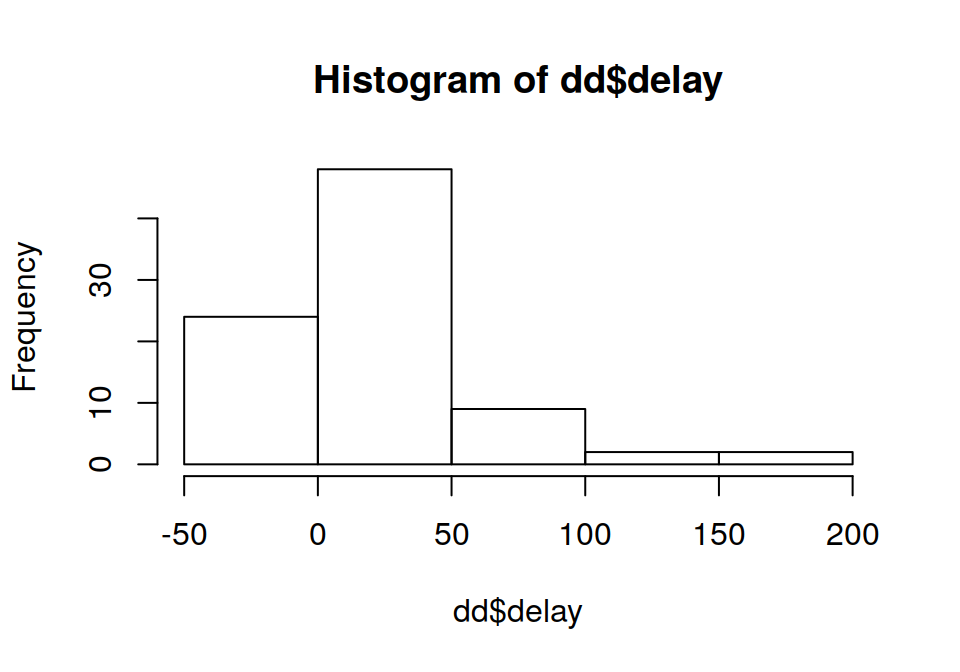

```r
dd <- flights %>%
  group_by(dest) %>%
  summarize(delay = mean(arr_delay, na.rm = TRUE))
hist(dd$delay)
```

## **$\Rightarrow$** Summarize exercises

1. Which carriers have the longest delays?
2. Which carriers have the most flights of distance greater than 1000?
3. Did any airplanes (as identified by `tailnum`) fly multiple times? If so, which planes flew the most flights?
4. Which destination cities have the fastest average flight speeds (`distance/air_time`)? Report only the cities having more than 10 flights.
5. Is speed correlated to how long the flight is?